# Appendix

This document provides graphs and summarizing tables of retention and class performance for a variety of STEM subjects at APU. Data are from Fall 2015 - Summer 2022 and are courtesy of APU’s Office of Institutional Research and Assessment.

**Freshmen retention** is defined as whether a student is enrolled in nonzero units in the following Fall. For example, freshmen starting in Fall 2019 are considered retained if they are taking classes in Fall 2020. Only first-time freshmen starting in a Fall semester are included in analyses using this definition.

**STEM retention** is defined as whether a student who declared a major in one of three STEM departments (Math and Physics, Biology and Chemistry, or Engineering and Computer Science) is enrolled in nonzero units and still has a major in one of those departments at least one year later.

*Note: because retention rates are nearly always above 50% in these data, most of the following visualizations have a truncated scale (50% - 100%) to make differences visibly easier to discern.*

# APU Freshmen Retention

## By Year

Historically, Freshman retention at APU has been high (>80%). The drop in the Fall 2019 cohort is among the freshman cohort for whom COVID hit in spring of their freshman year, and fewer returned for the fully online year in Fall 2020. The retention rate has increased the past two years but is not yet back at pre-pandemic levels.

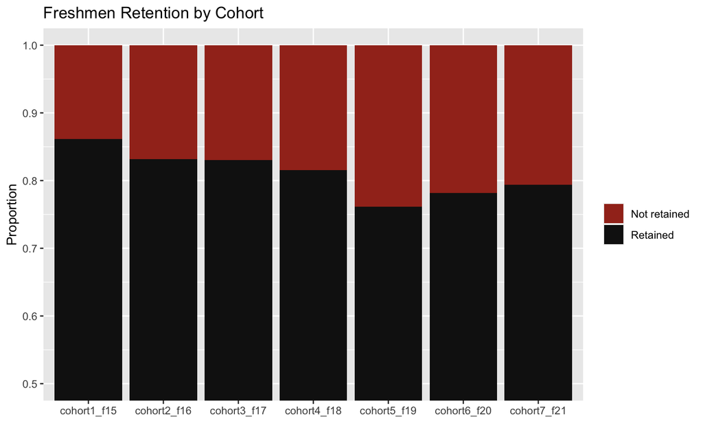

| cohort | n | prop |
| --- | --- | --- |
| cohort1_f15 | 1024 | 0.861 |
| cohort2_f16 | 931 | 0.832 |
| cohort3_f17 | 904 | 0.830 |
| cohort4_f18 | 898 | 0.816 |
| cohort5_f19 | 520 | 0.761 |
| cohort6_f20 | 479 | 0.781 |
| cohort7_f21 | 493 | 0.794 |

The overall decline in first-time freshman enrollment can be seen in the sample size column (n) above.

## By Sex

Freshmen retention is about 5 percentage points lower for males compared to females.

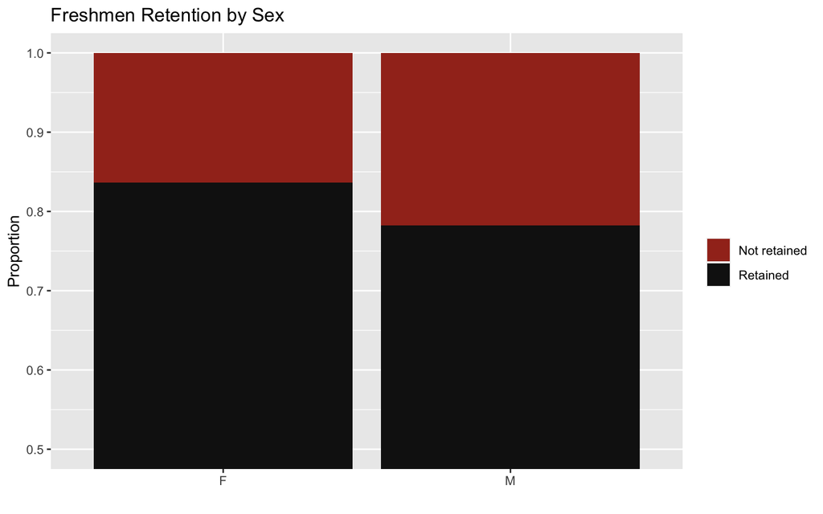

| sex | n | prop |
| --- | --- | --- |
| F | 3568 | 0.836 |
| M | 1681 | 0.782 |

## By First Generation Status

Freshmen retention is about 5 percentage points lower for first generation students compared to non first-generation students.

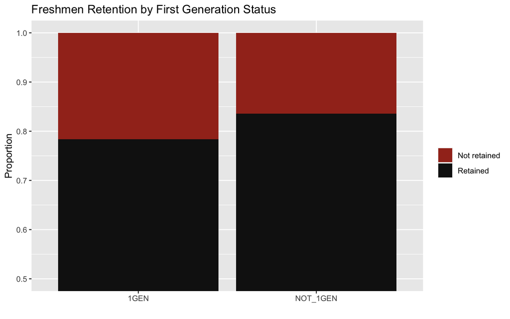

| first_gen | n | prop |
| --- | --- | --- |
| 1GEN | 1685 | 0.784 |
| NOT_1GEN | 3564 | 0.836 |

## By Commuter Status

Freshmen retention is 4 percentage points lower for commuters than for non-commuters.

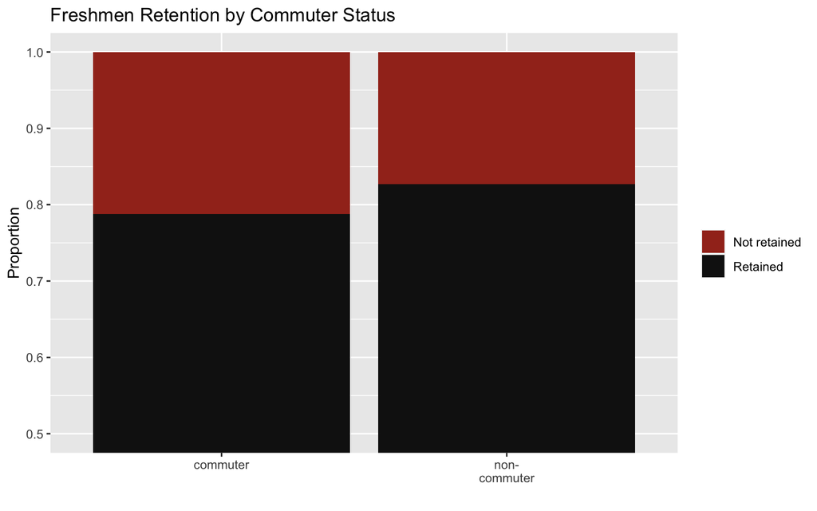

| commuter_status | n | prop |
| --- | --- | --- |
| commuter | 1136 | 0.788 |
| non-commuter | 4113 | 0.827 |

## By International Status

Freshmen retention is about 6.5 percentage points lower for international students compared to domestic students.

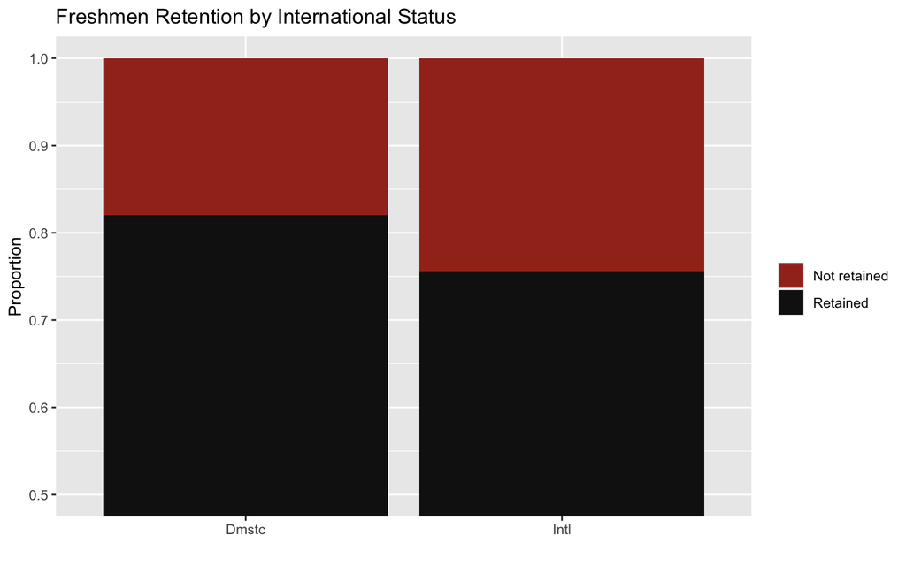

| intl | n | prop |
| --- | --- | --- |
| Dmstc | 5100 | 0.820 |
| Intl | 149 | 0.756 |

## By Ethnicity

Freshmen retention differs by ethnicity, with the highest retention rates among Asian (86%) and white students (84%) and the lowest retention rates among Black or African American (74%) and Native Hawaiian or Other Pacific Islander students (68%). Sample sizes can be seen in the table below.

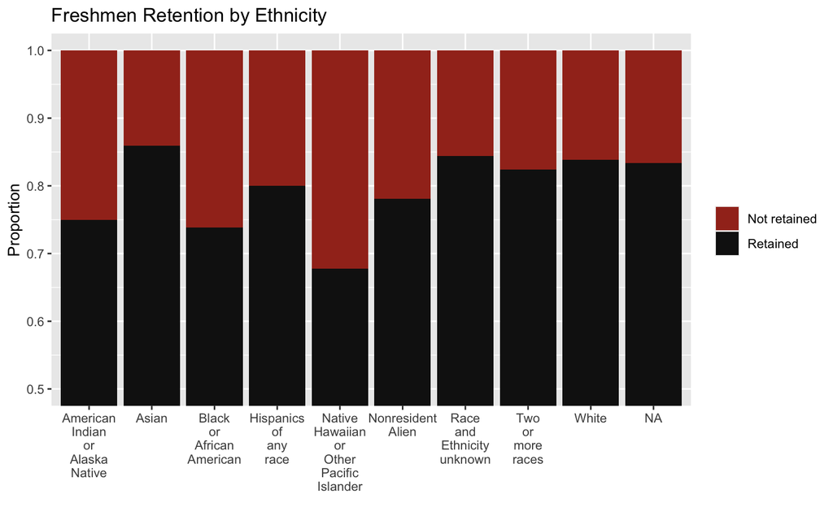

| ethnicity_ipeds | n | prop |
| --- | --- | --- |
| American Indian or Alaska Native | 12 | 0.750 |
| Asian | 551 | 0.860 |
| Black or African American | 243 | 0.739 |
| Hispanics of any race | 1663 | 0.800 |
| Native Hawaiian or Other Pacific Islander | 42 | 0.677 |
| Nonresident Alien | 150 | 0.781 |
| Race and Ethnicity unknown | 38 | 0.844 |
| Two or more races | 399 | 0.824 |
| White | 2091 | 0.838 |
| NA | 60 | 0.833 |

## Honors Students

Honors students have the highest retention rate among any subgroup (94%).

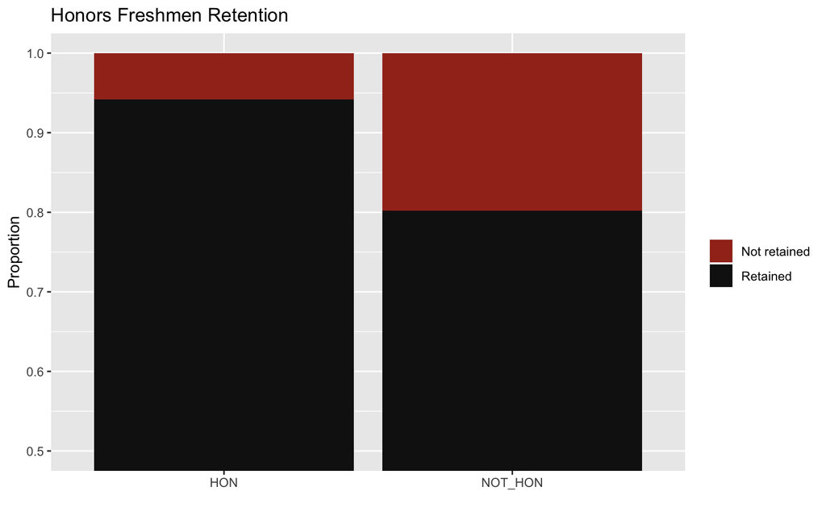

| honors | n | prop |
| --- | --- | --- |
| HON | 694 | 0.942 |
| NOT_HON | 4555 | 0.802 |

## Undeclared Students

Freshmen who entered with an undeclared major have retention rates that are 7.5 percentage points lower compared to freshman who enter with a declared major.

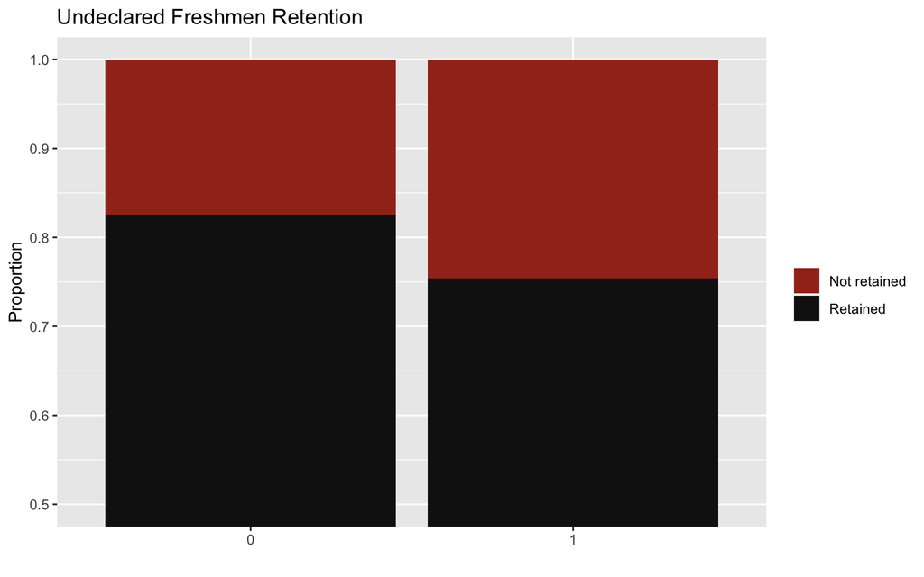

| was_undeclared | n | prop |
| --- | --- | --- |
| 0 | 4747 | 0.826 |
| 1 | 502 | 0.754 |

## By California Native Status

Freshmen retention is similar among out-of-state students compared to California native students.

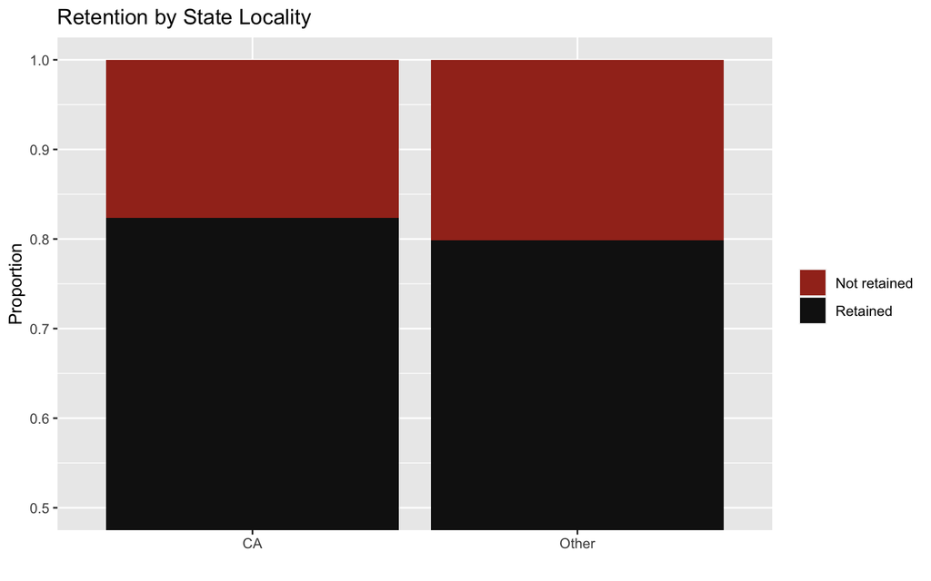

| CA_native | n | prop |
| --- | --- | --- |
| CA | 4143 | 0.824 |
| Other | 1106 | 0.799 |

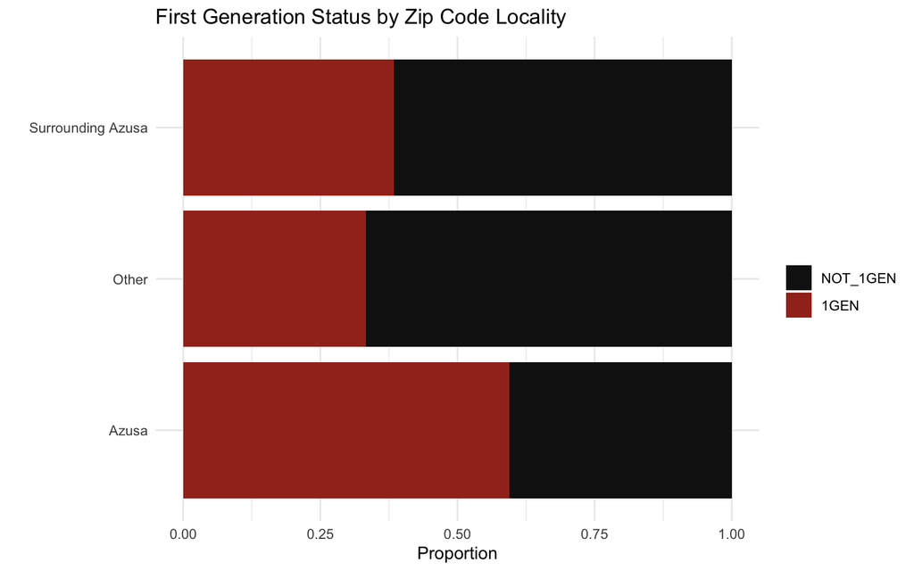

## By Zip Code

Freshmen retention differs somewhat by student (home) zip code, with lowest retention rates among students with an Azusa zipcode. This likely reflects the high proportion of first generation students among Azusa natives. “Surrounding Azusa” is defined as Glendora, Covina, West Covina, San Dimas, Baldwin Park, Arcadia, and El Monte.

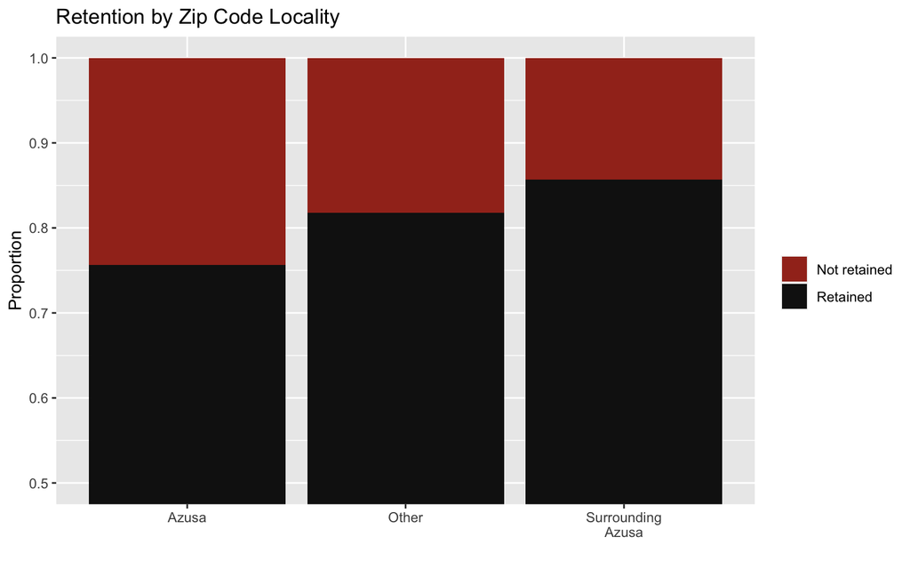

| azusa_native | n | prop |
| --- | --- | --- |
| Azusa | 28 | 0.757 |
| Other | 5125 | 0.818 |
| Surrounding Azusa | 96 | 0.857 |

## Freshman Retention by STEM Department

Freshmen retention is slightly lower (4 - 5 percentage points) among ECS majors compared to B&C and MPS majors.

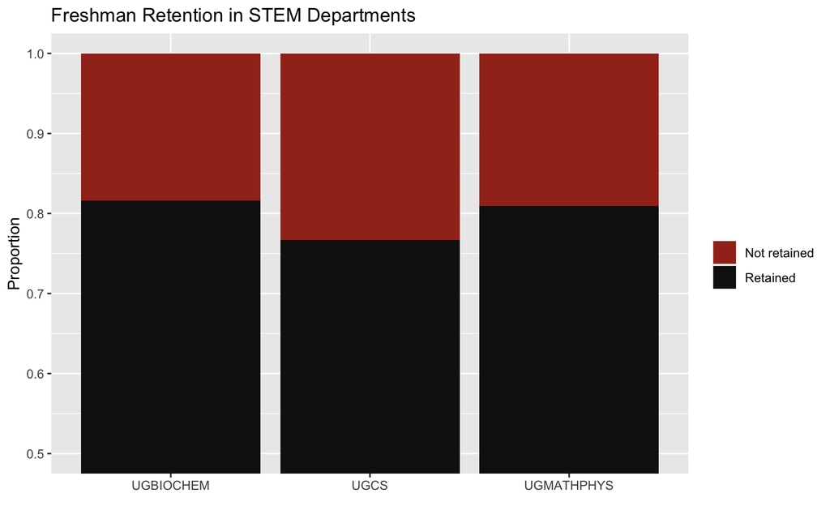

| first_org | n | prop |
| --- | --- | --- |
| UGBIOCHEM | 585 | 0.816 |
| UGCS | 161 | 0.767 |
| UGMATHPHYS | 51 | 0.810 |

There is significant variation in freshmen retention among different majors within departments. However, be cautious of the small sample sizes within some majors.

### Department of Biology and Chemistry

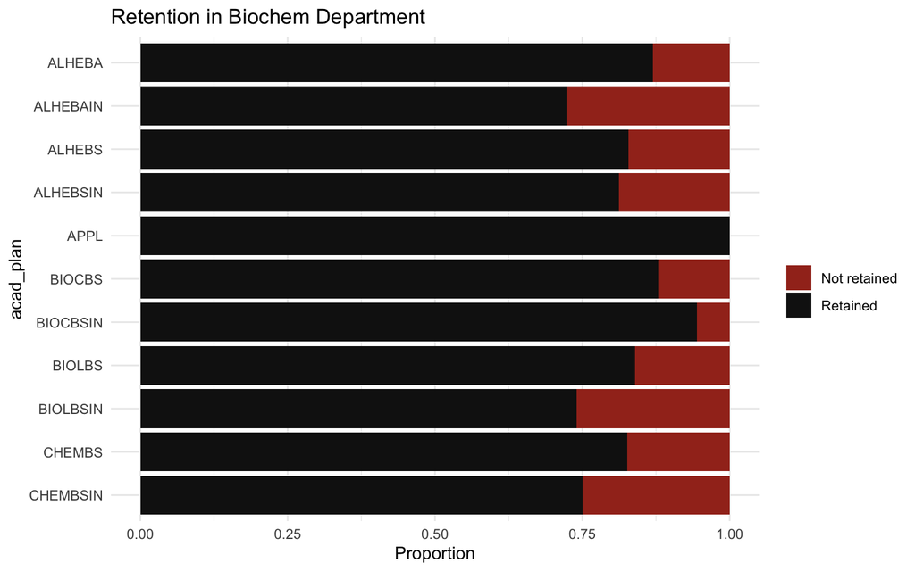

| acad_plan | n | prop |
| --- | --- | --- |
| ALHEBA | 154 | 0.870 |
| ALHEBAIN | 34 | 0.723 |
| ALHEBS | 116 | 0.829 |
| ALHEBSIN | 13 | 0.812 |
| APPL | 1 | 1.000 |
| BIOCBS | 65 | 0.878 |
| BIOCBSIN | 17 | 0.944 |
| BIOLBS | 215 | 0.840 |
| BIOLBSIN | 57 | 0.740 |
| CHEMBS | 19 | 0.826 |
| CHEMBSIN | 3 | 0.750 |

### Department of Engineering and Computer Science

[figure not shown]

| acad_plan | n | prop |
| --- | --- | --- |
| ENG2 | 8 | 0.889 |
| ENGR01 | 63 | 0.741 |
| SYSENG01 | 23 | 0.958 |
| UCIS | 12 | 0.632 |
| UCISBS | 6 | 1.000 |
| UCSI | 107 | 0.823 |
| XUCIS | 1 | 1.000 |

### Department of Mathematics, Physics, and Statistics

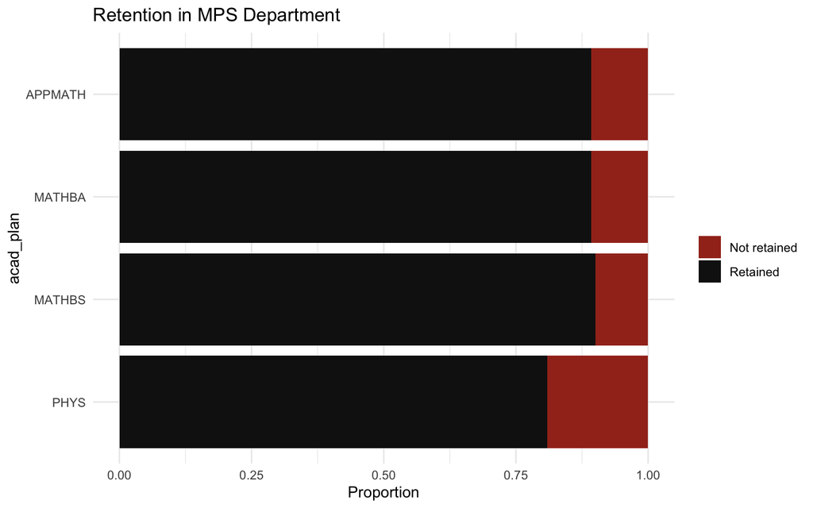

| acad_plan | n | prop |
| --- | --- | --- |
| APPMATH | 25 | 0.893 |
| MATHBA | 50 | 0.893 |
| MATHBS | 9 | 0.900 |
| PHYS | 17 | 0.810 |

# STEM Retention

Recall: STEM retention is defined as whether a student who declared a major in one of three STEM departments (Math and Physics, Biology and Chemistry, or Engineering and Computer Science) is enrolled in nonzero units and still has a major in one of those departments at least one year later.

Overall, STEM retention at APU is 61%. In other words, 4 in 10 students who start as a STEM major do not persist in a STEM major at APU.

## By Sex

STEM retention is sightly lower (4 percentage points) for females compared to males. This is in contrast to overall freshmen retention, which was 5 percentage points *higher* for females.

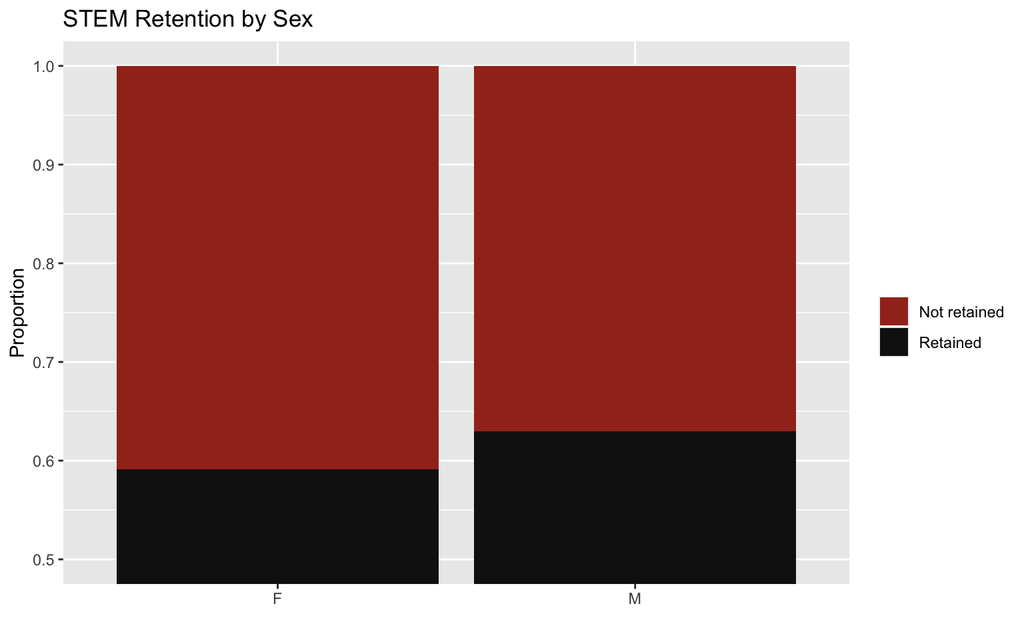

| sex | n | prop |
| --- | --- | --- |
| F | 689 | 0.591 |
| M | 570 | 0.630 |

## By First Generation Status

STEM retention is 16 percentage points lower for first generation students compared to continuing generation students.

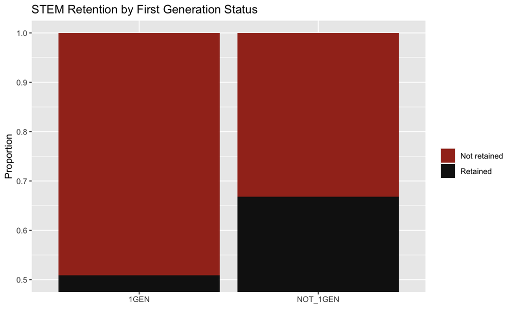

| first_gen | n | prop |
| --- | --- | --- |
| 1GEN | 399 | 0.509 |
| NOT_1GEN | 861 | 0.668 |

## By International Status

There is only a small number of international students who are STEM majors (total of 38 from 2015-2022), but they do have a 10 percentage point higher STEM retention rate compared to domestic students.

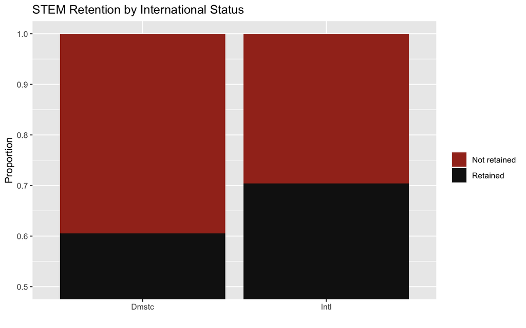

| intl | n | prop |
| --- | --- | --- |
| Dmstc | 1222 | 0.606 |
| Intl | 38 | 0.704 |

## By Ethnicity

STEM retention differs significantly by ethnicity. Among IPEDS ethnicity categories with at least 50 students, STEM retention is highest among Asian students (66%) and white students (64%) and lowest among students of two or more races (60%), Black students (59%), and Hispanic students of any race (56%).

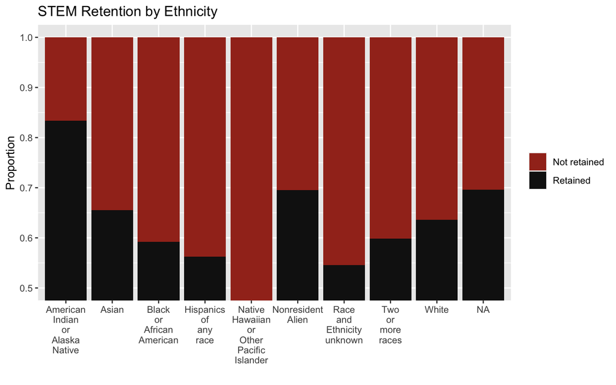

| ethnicity_ipeds | n | prop |
| --- | --- | --- |
| American Indian or Alaska Native | 5 | 0.833 |
| Asian | 173 | 0.655 |
| Black or African American | 58 | 0.592 |
| Hispanics of any race | 380 | 0.562 |
| Native Hawaiian or Other Pacific Islander | 9 | 0.360 |
| Nonresident Alien | 41 | 0.695 |
| Race and Ethnicity unknown | 12 | 0.545 |
| Two or more races | 94 | 0.599 |
| White | 472 | 0.636 |
| NA | 16 | 0.696 |

## By in-state vs. out-of-state

STEM retention does not differ for California students vs. out-of-state students.

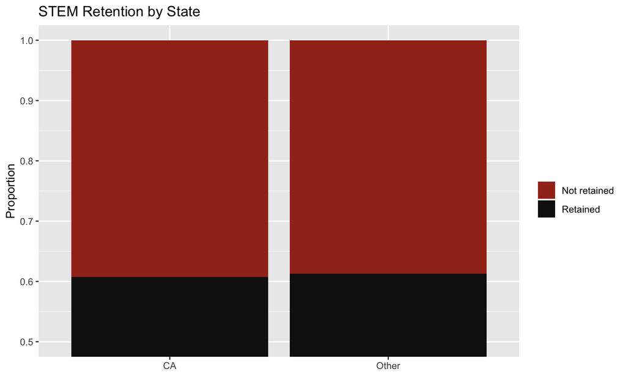

| CA_native | n | prop |
| --- | --- | --- |
| CA | 1059 | 0.607 |
| Other | 201 | 0.613 |

## By Zip Code

STEM retention is roughly similar for all zip-code categories.

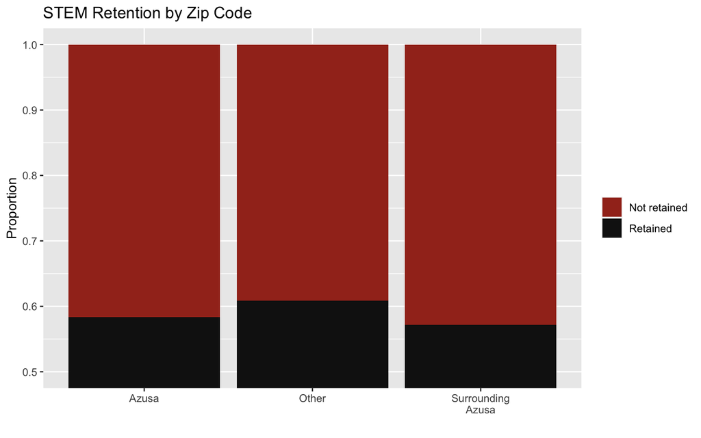

| azusa_native | n | prop |
| --- | --- | --- |
| Azusa | 7 | 0.583 |
| Other | 1233 | 0.609 |
| Surrounding Azusa | 20 | 0.571 |

## Student Movement by Department

The following Sankey diagram shows the movement of students between the 3 STEM departments as well as the undergraduate programs in business, educaiton, exercise science, and nursing.

The bars on the left represent a student’s first major, and the bars on the right represent their major in their last semester at APU. The heights of the bars are proportional to the number of students majoring in the department.

[interactive chart not shown]

Overall, there are more students who transfer out of STEM rather than into STEM. Only about 1.5% of students who start out as a non-STEM major switch to a STEM major.

[interactive chart not shown]

# DFWs and Retention

Graduation outcomes (right) by number of DFWs (left) is shown below. All students who ever declared a STEM major are included in this diagram. Notably, 1,058 of the 3,630 STEM students (29%) who left APU did not have any DFWs prior to leaving.

[interactive chart not shown]

# Class Progression and Retention

## Chemistry

### Calculus I to Chemistry 151

The grade outcome for CHEM 151 (right) by whether the student took Calculus at APU or not (left) is shown below. All students who took CHEM151 as a STEM major are included. Grades do not seem to differ much by where the STEM major took calculus.

[interactive chart not shown]

### General Chemistry I Retention

All students who took CHEM151 as a STEM major are included. Their retention status is determined one semester later.

[interactive chart not shown]

Note the fewer A’s and higher likelihood of leaving APU for first generation students in this and other introductory classes. Sex and commuter status appear to have less relationship with performance and retention.

[interactive chart not shown]

### General Chemistry II Retention

All students who took CHEM152 as a STEM major are included. Their retention status is determined one semester later.

[interactive chart not shown]

### Introductory Sequence

Only students with majors in the Biology and Chemistry department when taking these classes are included in this diagram. A student is considered retained if they are still in STEM one semester after the last of these classes that they have already taken.

[interactive chart not shown]

## Mathematics

### Calculus I Retention

All students who took this class as a STEM major are included. Their retention status is determined one semester later.

[interactive chart not shown]

### Calculus II Retention

All students who took this class as a STEM major are included. Their retention status is determined one semester later.

[interactive chart not shown]

### Introductory Statistics Retention

All students who took this class as a STEM major are included. Their retention status is determined one semester later.

[interactive chart not shown]

### Introductory Sequence

Only students with majors in the Department of Mathematics, Physics, and Statistics are included in this diagram. A student is considered retained if they are still in STEM one semester after the last of these classes that they have already taken.

[interactive chart not shown]

## Biology

### Biology 151

All students who took BIO151 as a STEM major are included. Their retention status is determined one semester later.

[interactive chart not shown]

### Biology 152

All students who took BIO152 as a STEM major are included. Their retention status is determined one semester later.

[interactive chart not shown]

### Introductory Sequence

Only students with majors in the Biology and Chemistry department when taking these classes are included in this diagram. A student is considered retained if they are still in STEM one semester after the last of these classes that they have already taken.

[interactive chart not shown]